# Composition Analysis of the French National Bibliography (BNF) dated 2025-08-05

# Overall summary

10,173,116 records and 445,215,666 attribute values in total. Constituent files:

- data/bnf/bnf.parquet (1.84GB)

## Temporal overview

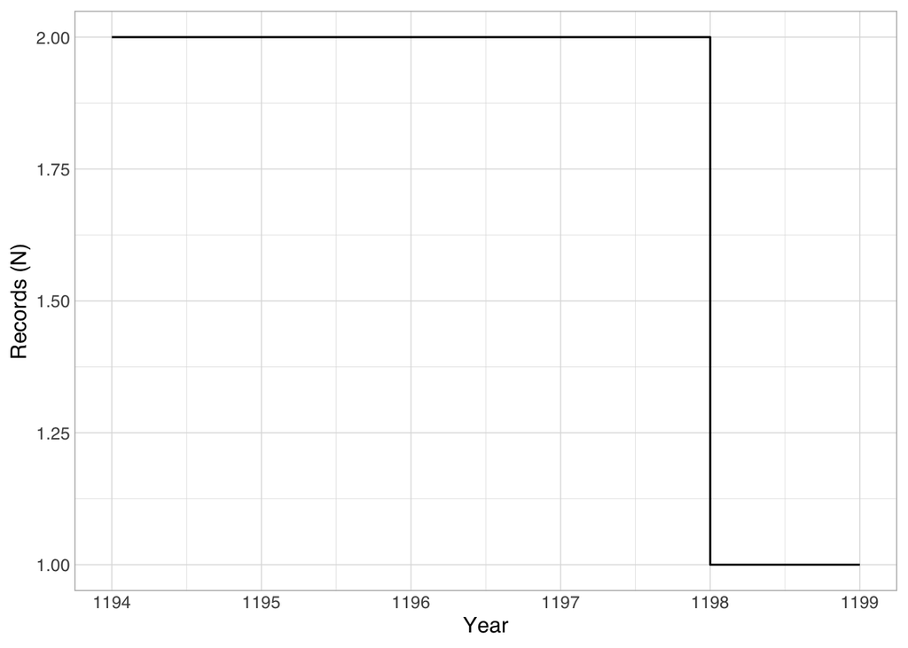

10,173,111 records do not have easily parseable dates between the years 1000 and 2050.

## Language overview

| [] | Records (N) | Proportion (%) |
| --- | --- | --- |
|  | 7092790 | 0.69720919332877 |
| NA | 2485120 | 0.24428306921891 |
| m?x | 125540 | 0.0123403684770723 |
| p? | 78530 | 0.00771936543336378 |
| m? | 75051 | 0.00737738565057157 |
| pm | 47565 | 0.00467555859974466 |
| pq | 45545 | 0.004476996035433 |
| pw | 27132 | 0.00266702945292278 |
| pa | 23486 | 0.00230863385417015 |
| pb | 22287 | 0.00219077419347229 |

[output cut: 445 more lines]

# Field code usage overview

In total, 255 distinct fields are used.

Legend for the table below:

- `records`: how many records have at least one of this field
- `r_p`: the above as a percentage of all records
- `n`: the total number of appearances of this field
- `vals_per_rec`: calculated from the above, the mean number of appearances of this field per record
- `recs_with_mult_vals`: the number of records that have more than one repetition of this field

| field_code | field_description | records | r_p | n | vals_per_rec | recs_with_mult_vals |
| --- | --- | --- | --- | --- | --- | --- |
| <a name="000">000</a> | NA | 303705 | 0.0298536849476601 | 303705 | 1 | 0 |
| <a name="001">001</a> | NA | 10173116 | 1 | 10173116 | 1 | 0 |
| <a name="003">003</a> | NA | 7687996 | 0.75571693078109 | 7688010 | 1.00000182102072 | 14 |
| <a name="008">008</a> | NA | 7687996 | 0.75571693078109 | 7687996 | 1 | 0 |
| <a name="009">009</a> | NA | 7687949 | 0.755712310761029 | 7950087 | 1.03409726053073 | 256761 |
| <a name="010">010</a> | NA | 2709 | 0.000266290092435789 | 2709 | 1 | 0 |
| <a name="015">015</a> | NA | 3162891 | 0.310906805741722 | 5866288 | 1.85472341601402 | 2147493 |
| <a name="016">016</a> | NA | 5 | 4.91491495820946e-07 | 5 | 1 | 0 |
| <a name="017">017</a> | NA | 542443 | 0.0533212242935203 | 4873683 | 8.98469147910472 | 542435 |
| <a name="018">018</a> | NA | 24951 | 0.00245264086244569 | 85594 | 3.43048374814637 | 24951 |

[output cut: 245 more lines]

# Field code usage overview by subfield

In total, 1,887 distinct field+subfield combinations are used.

Legend for the table below:

- `records`: how many records have at least one of this field+subfield
- `r_p`: the above as a percentage of all records
- `dist_vals`: the number of different values appearing in this field+subfield
- `e_vals`: at most seven random sample values of this field+subfield
- `n`: the total number of appearances of this field+subfield
- `vals_per_rec`: calculated from the above, the mean number of appearances of this field+subfield per record
- `recs_with_mult_vals`: the number of records that have more than one repetition of this field+subfield

| subfield_code | subfield_description | records | r_p | dist_vals | e_vals | n | vals_per_rec | recs_with_mult_vals |
| --- | --- | --- | --- | --- | --- | --- | --- | --- |
| 000: NA |  |  |  |  |  |  |  |  |
| 000$ | NA | 303,705 | 2.99% | 67 | n d922 45a (2)\| n0 d922 45r (11259)\| n0 d922 h 45a (587)\| c2 d922 2 45a (6)\| n0 d922 345r (1)\| n0 d922 45is (7061)\| c6 d922 45a (15) | 303,705 | 1 | 0 |
| 001: NA |  |  |  |  |  |  |  |  |
| 001$ | NA | 10,173,116 | 100% | 10,165,564 | FRBNF426526480000008 (1)\|FRBNF454780770000001 (1)\|FRBNF310128300000000 (1)\|FRBNF395974460000009 (1)\|FRBNF422100930000006 (1)\|FRBNF413027490000002 (1)\|FRBNF384861570000003 (1) | 10,173,116 | 1 | 0 |
| 003: NA |  |  |  |  |  |  |  |  |
| 003$ | NA | 7,687,996 | 75.57% | 7,682,244 | http://catalogue.bnf.fr/ark:/12148/cb43777593f (1)\|http://catalogue.bnf.fr/ark:/12148/cb47173902z (1)\|http://catalogue.bnf.fr/ark:/12148/cb38295147t (1)\|http://catalogue.bnf.fr/ark:/12148/cb3795632… | 7,688,010 | 1 | 14 |
| 008: NA |  |  |  |  |  |  |  |  |
| 008$ | NA | 7,687,996 | 75.57% | 2,507,340 | 130304c 2012 frfre bk 7b (1)\|020323m 1925 1949 fr b 001 (1)\|241109s 2022 esspa b 001 (1)\|220624s 1869 frfre b 001 (1)\|981130s 1949 fr b 001 (1)\|980811s 1992 .... ....itita b 001 (1)\|941006s 1990… | 7,687,996 | 1 | 0 |
| 009: NA |  |  |  |  |  |  |  |  |
| 009$ | NA | 7,687,949 | 75.57% | 57,421 | ae f l z 1 a zz (1)\|ge v acc (5)\|sd z 1 m zmm c (7)\|hv d 1 2cvV12b rd (49)\|c x c dui (3)\|sa s 1 m ab c (1)\|hvt d s 1 2do x rj (5) | 7,950,087 | 1.03 | 256,761 |
| 010: NA |  |  |  |  |  |  |  |  |
| 010$a | NA | 2,709 | 0.03% | 3 | MONx03 (43)\|MONx06 (2665)\|MONx15 (1) | 2,709 | 1 | 0 |
| 015: NA |  |  |  |  |  |  |  |  |
| 015$a | NA | 3,162,890 | 31.09% | 3,136,075 | 02261336 (1)\|10501037 (1)\|00019047 (1)\|00964892 (1)\|01053542 (1)\|11201530 (1)\|01673998 (1) | 3,163,121 | 1 | 220 |
| 015$d | NA | 2,147,040 | 21.11% | 252 | 20210429 (2764)\|20241003 (234)\|19910101 (1)\|20240905 (221)\|20210517 (480)\|20200806 (3323)\|20190101 (81383) | 2,147,055 | 1 | 15 |
| 015$n | NA | 551,883 | 5.42% | 166 | 08/2025 (2552)\|09/2021 (2733)\|23/2021 (3170)\|06/2024 (3853)\|03/2021 (5035)\|13/2024 (2814)\|05/2022 (4548) | 551,884 | 1 | 1 |
| 015$z | NA | 4,228 | 0.04% | 1 | r (4228) | 4,228 | 1 | 0 |
| 016: NA |  |  |  |  |  |  |  |  |
| 016$a | NA | 5 | 0% | 5 | 60713 (1)\|54884 (1)\|58243 (1)\|0000-0005-B3E6-0000-G-0000-0000-Q (1)\|0000-0005-C97F-0000-Z-0000-0000-6 (1) | 5 | 1 | 0 |
| 017: NA |  |  |  |  |  |  |  |  |
| 017$a | NA | 542,358 | 5.33% | 540,189 | 36621803 (1)\|494047125 (1)\|852829251 (1)\|938669993 (1)\|ocm57469842 (1)\|840927675 (1)\|1241731477 (1) | 542,375 | 1 | 17 |
| 017$b | NA | 1 | 0% | 1 | br. (1) | 1 | 1 | 0 |
| 017$d | NA | 6,018 | 0.06% | 101 | 20230103 (7)\|20220407 (1)\|20190816 (9)\|20210216 (2)\|20220214 (2)\|20210520 (4)\|20210326 (1) | 6,018 | 1 | 0 |
| 017$e | NA | 21 | 0% | 17 | 19950117 (1)\|20061128 (2)\|19950128 (1)\|20050314 (1)\|19950201 (1)\|19910319 (1)\|19950208 (1) | 21 | 1 | 0 |
| 017$k | NA | 460,952 | 4.53% | 2,550 | SzZuIDS BS/BE B460 (2)\|RCE (26)\|OBE (33)\|QPE (1)\|MH-HY (2)\|AS0 (3)\|HUA (502) | 460,960 | 1 | 8 |
| 017$l | NA | 447,678 | 4.4% | 34 | cat (216)\|por (38)\|chi (1506)\|rus (4)\|vie (4)\|dut (4037)\|bul (2) | 447,685 | 1 | 7 |
| 017$m | NA | 389,894 | 3.83% | 5,146 | TETON (8)\|CON (2)\|VXO (3)\|ONE (9)\|GXR (291)\|KFS (1)\|ALK (14) | 2,557,918 | 6.56 | 333,662 |
| 017$n | NA | 315,534 | 3.1% | 65 | ncr/1977 (4)\|ncr/1987 (808)\|local ; pn (5)\|onix/3.0 (602)\|rda809/.93358 (1)\|ISBD(M) (9)\|isbd (8) | 315,538 | 1 | 4 |
| 017$o | NA | 542,438 | 5.33% | 54 | Bibliothèques du Havre (10)\|PICA (2)\|x (1)\|Paris, BHVP (4)\|Paris, musée Air France (1)\|BDF (7)\|Paris, Société de l'histoire du protestantisme français (4) | 542,455 | 1 | 17 |
| 017$q | NA | 15 | 0% | 4 | ukscp (1)\|pcc (10)\|lccopycat (1)\|Abes (3) | 15 | 1 | 0 |

[output cut: 2112 more lines]